# Enteropathogen antibody dynamics and force of infection among children in low-resource settings

Asembo, Kenya Antibody distributions, Figure 1 - supplement 3

# Notebook Summary

This script summarizes the distribution of antibody responses in the Asembo, Kenya cohort.

It fits Gaussian mixture models to the distributions, and where possible, estimates seropositivity cutoffs based on the mixture model fits.

For Giardia and Cryptosporidium antigens, the CDC lab estimated cutoff values using a receiver operator characteristic (ROC) curve approach with known positive and negative specimens. For these antigens, the script compares the classification of measurements by cutoff values derived from ROC and mixture models.

# Script preamble

```r
#-----------------------------
# preamble
#-----------------------------
library(here)
here::here()
```

```
## [1] "/Users/benarnold/enterics-seroepi"
```

```r
# load packages
library(tidyverse)
library(viridis)
library(mixtools)

# set up for parallel computing
# configure for a laptop (use only 3 cores)
library(foreach)
library(doParallel)
registerDoParallel(cores=3)

# bright color blind palette:  https://personal.sron.nl/~pault/
cblack <- "#000004FF"
cblue <- "#3366AA"
cteal <- "#11AA99"
cgreen <- "#66AA55"
cchartr <- "#CCCC55"
cmagent <- "#992288"
cred <- "#EE3333"
corange <- "#EEA722"
cyellow <- "#FFEE33"
cgrey <- "#777777"

# safe color blind palette
# http://jfly.iam.u-tokyo.ac.jp/color/
# http://www.cookbook-r.com/Graphs/Colors_(ggplot2)/
cbPalette <- c("#999999", "#E69F00", "#56B4E9", "#009E73", "#F0E442", "#0072B2", "#D55E00", "#CC79A7")

# viridis color palette
vircols <- viridis(n=7,alpha=1,begin=0.2,end=0.97)
```

#Load the formatted data

```r
#-----------------------------
# load the formatted data
# created with
# asembo-enteric-ab-data-format.Rmd
#-----------------------------
dl <- readRDS(here::here("data","asembo_analysis.rds"))

# list the enteric antigens and make formatted labels for them
mbavars <- c("vsp3","vsp5","cp17","cp23","salb","sald","etec","cholera","p18","p39","leca")

mbalabs <- c("Giardia VSP-3","Giardia VSP-5","Cryptosporidium Cp17","Cryptosporidium Cp23","Salmonella LPS group B","Salmonella LPS group D","ETEC LT B subunit","Cholera toxin B subunit","Campylobacter p18","Campylobacter p39","E. histolytica LecA")

# re-order the antigen factor for these plots
dl <- dl %>%
  mutate(antigenf=factor(antigenf,levels=mbalabs))
```

# Distribution of antibody levels

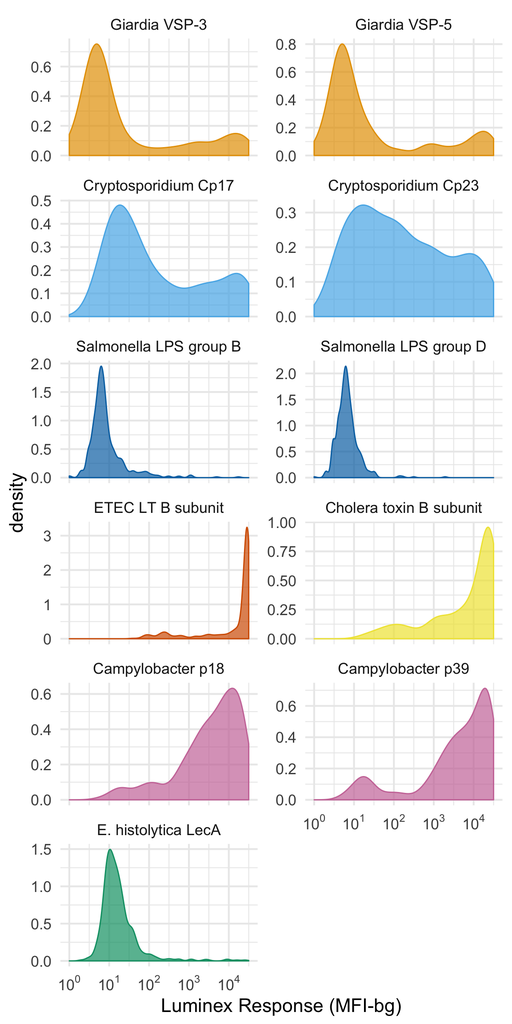

```r
# custom color blind color palette is in the preamble chunck
# pcols <- c(cred,corange,cgreen,cteal,cblue,cgrey,cmagent)
# pcols <- c(corange,cred,cmagent,cblue,cteal,cgreen,cgrey)
# pcols <- vircols
pcols <- cbPalette[c(2:4,6,7,5,8,1)]


# custom log labels
log10labs <- c(
  expression(10^0),
  expression(10^1),
  expression(10^2),
  expression(10^3),
  expression(10^4)
)

p <- ggplot(data=dl,aes(x=logmfi,group=pathogen,color=pathogen,fill=pathogen)) +
  facet_wrap(~antigenf,nrow=6,ncol=2,scales="free_y") +
  geom_density(aes(y=..density..),alpha=0.7) +
  scale_x_continuous(limits = c(0,4.5),breaks = 0:4,labels=log10labs) +
  scale_fill_manual(values=pcols) +
  scale_color_manual(values=pcols) +
  labs(x="Luminex Response (MFI-bg)") +
  theme_minimal(base_size=16) +
  theme(legend.position = "none")

p
```

#Seropositivity cutoff values

## ROC-based cutoffs

```r
#-----------------------------
# add cutoff values for
# those with an ROC cutoff
# provided by Jeff Priest CDC
#-----------------------------
dl$roccut <- NA
dl$roccut[dl$antigen %in% "vsp3"] <- log10(651)
dl$roccut[dl$antigen %in% "vsp5"] <- log10(451)
dl$roccut[dl$antigen %in% "cp17"] <- log10(428)
dl$roccut[dl$antigen %in% "cp23"] <- log10(1380)
```

## Mixture-model based cutoffs

```r
#-----------------------------
# mixture models
#-----------------------------
fitmix <- function(x,lambda,k) {
  mixfit <- normalmixEM(x,lambda=lambda,k=k)
  mixcut <- mixfit$mu[order(mixfit$mu)][1]+3*mixfit$sigma[order(mixfit$mu)][1]
  cat(summary(mixfit),"\nCutoff value:",mixcut,"(log10 MFI), or:",
      round(10^mixcut),"(MFI)\n\n")
  # pull out fitted densities
  denmat <- matrix(NA,nrow=length(x),ncol=k)
  denord <- order(mixfit$mu)
  for(i in 1:k) {
    j <- denord[i]
    denmat[,i] <- mixfit$lambda[j] * dnorm(x,mean=mixfit$mu[j],sd=mixfit$sigma[j])
  }
  denmat <- data.frame(denmat)
  colnames(denmat) <- paste("den",1:k,sep="")
  # return original values plus fitted densities in a dataframe
  # also return the cutoff value and normalmixEM object
  xden <- data.frame(x=x,denmat)
  list(xden=xden,mixcut=mixcut,mixfit=mixfit)

}

#-----------------------------
# mixture model fits
# store densities of mixture distributions
# and estimated cutoffs
#-----------------------------
set.seed(1234)
mixdens <- foreach(ab=mbavars,.combine=rbind) %do% {
  cat("\n\n Mixture model fit for ",ab,"\n\n")
  mixf <- fitmix(x=dl$logmfi[dl$antigen==ab],lambda=0.5,k=2)
  di <- mixf$xden
  di$mixcut <- mixf$mixcut
  di$antigen=ab
  di <- di %>% arrange(x) %>% select(antigen,mixcut,everything())
  di
}
```

```
##
##
##  Mixture model fit for  vsp3
##
## number of iterations= 38
## summary of normalmixEM object:
##          comp 1   comp 2
## lambda 0.722503 0.277497
## mu     0.707761 3.408623
## sigma  0.303598 0.882467
## loglik at estimate:  -480.4285
##
## Cutoff value: 1.618554 (log10 MFI), or: 42 (MFI)
##
##
##
##  Mixture model fit for  vsp5
##
## number of iterations= 23
## summary of normalmixEM object:
##          comp 1   comp 2
## lambda 0.750191 0.249809
## mu     0.778484 3.576080
## sigma  0.346602 0.796041
## loglik at estimate:  -491.9993
##
## Cutoff value: 1.818289 (log10 MFI), or: 66 (MFI)
##
##
##
##  Mixture model fit for  cp17
##
## number of iterations= 104
## summary of normalmixEM object:
##          comp 1   comp 2
## lambda 0.622480 0.377520
## mu     1.352001 3.520468
## sigma  0.407841 0.750301
## loglik at estimate:  -590.1734
##
```

[output cut: 98 more lines]

```
## Cutoff value: 2.6149 (log10 MFI), or: 412 (MFI)
##
##
##
##  Mixture model fit for  leca
##
## number of iterations= 51
## summary of normalmixEM object:
##          comp 1    comp 2
## lambda 0.902660 0.0973401
## mu     1.135886 2.1522899
## sigma  0.252314 0.9075963
## loglik at estimate:  -154.0261
##
## Cutoff value: 1.892829 (log10 MFI), or: 78 (MFI)
```

```r
mixcuts <- mixdens %>%
  group_by(antigen) %>% filter(row_number()==1) %>% select(antigen,mixcut) %>% ungroup()

#-----------------------------
# Distributions for p18,ETEC
# and Cholera do not allow
# for reasonable mixture cutoffs
#-----------------------------
mixcuts$mixcut[mixcuts$antigen %in% c("p18","etec","cholera")] <- NA

#-----------------------------
# merge in the mixture cutoffs
# to the main dataset
#-----------------------------
dl <- left_join(dl,mixcuts,by=c("antigen"))
```

### Figure of antibody mixture distributions

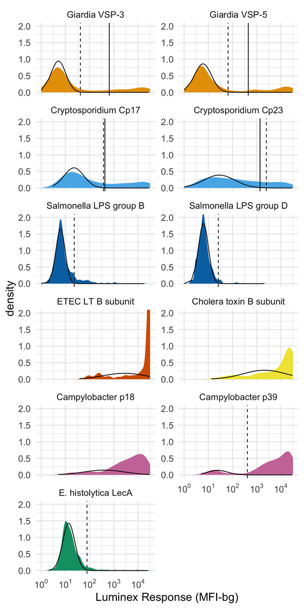

```r
#-----------------------------
# Get the mixture density distributions
# set the pathogen field to an arbitrary value (Giardia) to
# mesh with the global ggplot aesthetics
#-----------------------------
plotmixdens <- mixdens %>%
  mutate(antigenf=factor(antigen,levels=mbavars,labels=mbalabs),
         pathogen="Giardia"
         )

#-----------------------------
# custom color blind color palette (pcols)
# and custom log10 labels (log10labs)
# defined in a previous code chunk
#-----------------------------
# pcols <- c(cred,corange,cgreen,cteal,cblue,cgrey,cmagent)
# pcols <- c(corange,cred,cmagent,cblue,cteal,cgreen,cgrey)
# pcols <- vircols
pcols <- cbPalette[c(2:4,6,7,5,8,1)]

pmix <- ggplot(data=dl,aes(x=logmfi,group=pathogen,color=pathogen,fill=pathogen)) +
  facet_wrap(~antigenf,nrow=6,ncol=2,scales="free_y") +
  # plot empirical smoothed distribution
  geom_density(aes(y=..density..),color=NA,alpha=1)+
  # plot fitted mixture distributions
  geom_line(data=plotmixdens,aes(x=x,y=den1),color=cblack) +
  # geom_line(data=plotmixdens,aes(x=x,y=den2p),color=cblack) +
  # add vertical lines for the cutoff values
  geom_vline(aes(xintercept=roccut)) +
  geom_vline(aes(xintercept=mixcut),linetype=2) +
  # labels and formatting
  scale_x_continuous(limits = c(0,4.5),breaks = 0:4,labels=log10labs) +
  coord_cartesian(ylim=c(0,2)) +
  labs(x="Luminex Response (MFI-bg)") +
  scale_fill_manual(values=pcols) +
  scale_color_manual(values=pcols) +
  theme_minimal(base_size = 16) +
  theme(legend.position = "none")

pmix
```

## Cutoffs derived from presumed seroconverters

Children whose antibody levels increased by at least 2 on the log10 scale presumably seroconverted during the study and are assumed unexposed at their first measurement. Use the unexposed measurements to estimate the mean and standard deviation among the unexposed measurements, and use the mean plus 3 standard deviations to create a seropositivity cutoff.

Note that the use of +2 log10 change in MFI is conservative assumption for many antibodies in this analysis. We conducted a sensitivity analysis in this study wherby we compared classification agreement with ROC-based and mixture model-based classification across a range of possible changes to use as the threshold. In that sensitivity analysis, a change of between 0.5 and 1.75 on the log10 scale led to the maximum agreement with ROC-based and mixture model-based classification for most antigens (see computational notebook: asembo-enteric-ab-fold-change-analysis.nb.html).

```r
#-----------------------------
# subset the data to the first
# measurement and children/
# antigens with a change of
# 2 or more on the log10 MFI scale
#-----------------------------
dl <- dl %>%
  mutate(unexp = ifelse(time=="A" & logmfidiff>=2,"Presumed unexposed","Possibly exposed"))

dlunexp <- dl %>%
  filter(unexp=="Presumed unexposed")

#-----------------------------
# calculate the mean and SD
# of each distribution
#-----------------------------
unexp_dists <- dlunexp %>%
  group_by(pathogen,antigen,antigenf) %>%
  summarize(n = n(),
            unexp_mean = mean(logmfi),
            unexp_sd = sd(logmfi),
            unexpcut = unexp_mean + 3*unexp_sd) %>%
  ungroup()
#-----------------------------
# print values
#-----------------------------
select(unexp_dists,antigenf,n,starts_with("unexp"))
```

| antigenf | n | unexp_mean | unexp_sd | unexpcut |
| --- | --- | --- | --- | --- |
| Giardia VSP-3 | 58 | 0.6408525 | 0.3446237 | 1.674724 |
| Giardia VSP-5 | 56 | 0.6862365 | 0.3268907 | 1.666909 |
| Cryptosporidium Cp17 | 53 | 1.2727355 | 0.3692017 | 2.380340 |
| Cryptosporidium Cp23 | 46 | 0.9929224 | 0.4561537 | 2.361384 |
| E. histolytica LecA | 5 | 1.0452679 | 0.1593533 | 1.523328 |
| Salmonella LPS group B | 4 | 0.5000000 | 0.3364493 | 1.509348 |
| Salmonella LPS group D | 1 | 0.4771213 | NA | NA |
| ETEC LT B subunit | 18 | 2.1032383 | 0.2297778 | 2.792572 |
| Cholera toxin B subunit | 14 | 1.7466457 | 0.3877231 | 2.909815 |
| Campylobacter p18 | 14 | 1.3229614 | 0.2639300 | 2.114752 |

[output cut: 1 more lines]

```r
#-----------------------------
# merge the cutoff values
# based on presumed unexposed
# back to the main data
# exclude those with very few
# observations (i.e., <10)
#-----------------------------
dlunexp2 <- unexp_dists %>%
  ungroup() %>%
  filter(n>10) %>%
  select(antigen,unexpcut)

dl <- left_join(dl,dlunexp2,by="antigen")
```

### Figure of distributions and cutoffs from presumed unexposed

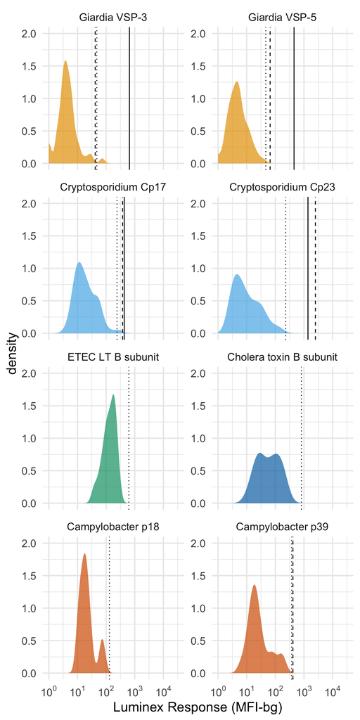

```r
#-----------------------------
# create a figure of the
# unexposed distributions
#-----------------------------
# pcols <- c(cred,corange,cblue,cgrey,cmagent)
# pcols <- c(corange,cred,cteal,cgreen,cgrey)
# pcols <- vircols[c(1:5)]
pcols <- cbPalette[c(2:4,6,7,5,8,1)]


punexp <- ggplot(data=filter(dl,unexp=="Presumed unexposed" & !is.na(unexpcut)), aes(x=logmfi,group=pathogen,color=pathogen,fill=pathogen)) +
  facet_wrap(~antigenf,nrow=6,ncol=2,scales="free_y") +
  # plot empirical smoothed distribution
  geom_density(aes(y=..density..),color=NA,alpha=0.7)+
  # add vertical lines for the cutoff values
  geom_vline(aes(xintercept=roccut)) +
  geom_vline(aes(xintercept=mixcut),linetype=2) +
  geom_vline(aes(xintercept=unexpcut),linetype=3) +
  # labels and formatting
  scale_x_continuous(limits = c(0,4.5),breaks = 0:4,labels=log10labs) +
  coord_cartesian(ylim=c(0,2)) +
  labs(x="Luminex Response (MFI-bg)") +
  scale_fill_manual(values=pcols) +
  scale_color_manual(values=pcols) +
  theme_minimal(base_size = 16) +
  theme(legend.position = "none")

punexp
```

## Fig 1 - supp 3. Antibody distributions and cutoff values

**This is Figure 1, supplement 3 in the main text.**

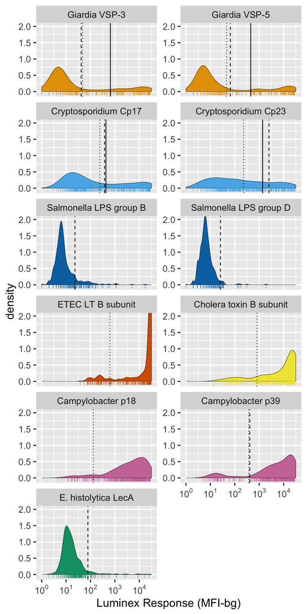

```r
#-----------------------------
# Get the mixture density distributions
# Mixtures istributions for p18, ETEC
# and Cholera did not have reasonable
# fits, so set them to missing
#-----------------------------
plotmixdens <- plotmixdens %>%
  mutate(den1p = ifelse(antigen %in% c("p18","etec","cholera"),NA,den1),
         den2p = ifelse(antigen %in% c("p18","etec","cholera"),NA,den2)
         )

#-----------------------------
# create a figure of the
# unexposed distributions
#-----------------------------
pcols <- cbPalette[c(2:4,6,7,5,8,1)]

pall <- ggplot(data=dl,aes(x=logmfi,group=pathogen,color=pathogen,fill=pathogen)) +
  facet_wrap(~antigenf,nrow=6,ncol=2,scales="free_y") +
  # plot empirical smoothed distribution and rug plot
  geom_density(aes(y=..density..),color="black",size=0.2,alpha=1)+
  geom_point(aes(y=-0.05),pch="|")+
  # add vertical lines for the cutoff values
  geom_vline(aes(xintercept=roccut)) +
  geom_vline(aes(xintercept=mixcut),linetype=2) +
  geom_vline(aes(xintercept=unexpcut),linetype=3) +
  # labels and formatting
  scale_x_continuous(limits = c(0,4.5),breaks = 0:4,labels=log10labs) +
  coord_cartesian(ylim=c(-0.05,2)) +
  labs(x="Luminex Response (MFI-bg)") +
  scale_fill_manual(values=pcols) +
  scale_color_manual(values=pcols) +
  theme_grey(base_size = 16) +
  theme(legend.position = "none")

pall
```

```r
# save a PDF version
ggsave(here::here("figs","Fig1sup3-asembo-ab-distributions.pdf"),plot=pall,device=cairo_pdf,width=7,height=14)
# save a TIFF version
ggsave(here::here("figs","Fig1sup3-asembo-ab-distributions.TIFF"),plot=pall,device="tiff",width=7,height=14)
#-----------------------------
# create composite measures of
# seropositivity
#-----------------------------
dl <- dl %>%
  mutate(posroc = ifelse(logmfi > roccut,1,0),
         posmix = ifelse(logmfi > mixcut,1,0),
         posunex = ifelse(logmfi > unexpcut,1,0))

#-----------------------------
# hierarchy of information for
# cutoffs:
# 1. ROC
# 2. mixture model based
# 3. estimated among presumed unexposed
# store the cutoff value used
#-----------------------------
dl <- dl %>%
  mutate(seropos=ifelse(!is.na(posroc),posroc,posmix),
         serocut=ifelse(!is.na(posroc),roccut,mixcut),
         serocut_desc=ifelse(!is.na(posroc),"ROC","Mixture Model")) %>%
  mutate(seropos=ifelse(!is.na(seropos),seropos,posunex),
         serocut_desc=ifelse(!is.na(serocut),serocut_desc,"Unexp dist"),
         serocut=ifelse(!is.na(serocut),serocut,unexpcut)) %>%
  filter(!is.na(seropos)) %>%
  mutate(antigenf=factor(antigenf),
         childid = factor(childid))
```

```r
#-----------------------------
# save an updated dataset
# that includes cutoff values
# and seropositive indicators
#-----------------------------
saveRDS(dl,file=here::here("data","asembo_analysis2.rds"))
```